# Analyzing the Trichopetra data set with Poisson log-normal Network inference

Julien Chiquet

2018-07-09

This vignette intends to illustrate the basical use of the `PLNnetwork` function and the methods accompaning the R6 Classes `PLNnetworkfamily` and `PLNnetworkfit`. To this end, let us consider an ecological data set concerning abundances of Trichopetera species, coupled with some meteological factors that may influence the presence their presence.

## The Trichoptera data set

This data set comes with the `R` package *ade4*. We also load our own package for the upcoming analyses:

```r
library(PLNmodels)
library(ade4)
data("trichometeo")
```

The insects have been trapped between 1959 and 1960 during 49 trapping nights. These trapping nights are the observations in the case at hand. For each one of these, the abundance of 17 Trichoptera species is recorded, which forms the first table:

```r
dim(trichometeo$fau)
```

```
## [1] 49 17
```

```r
head(trichometeo$fau)
```

```
##   Che Hyc Hym Hys Psy Aga Glo Ath Cea Ced Set All Han Hfo Hsp Hve Sta
## 1   0   0   5   0  17   0   0   0   0   2   0   1   0   1   2   0   1
## 2   0   0   3   0   8   0   0   0   0   0   0   2   0   0   0   0   0
## 3   0   0   1   0  32   0   0   0   0   0   0   4   0   0   1   0   0
## 4   0   0   3   0 176   4   0   0   0   1   0   3   0   0   3   0   2
## 5   0   0   4   0  69   2   0   0   0   0   0   1   0   0   1   0   2
## 6   0   0   2   0  14   1   0   0   0   0   0   1   0   0   0   0   0
```

The second table concerns 11 meteorological variables which may influence the abundance of each species:

```r
dim(trichometeo$meteo)
```

```
## [1] 49 11
```

```r
head(trichometeo$meteo)
```

```
##   T.max T.soir T.min Vent Pression Var.Pression Humidite Nebu.Nuit
## 1  22.2   18.7  11.0 -2.3    998.5          4.1       60        19
## 2  24.2   19.8   8.4 -2.7    999.5         -1.1       63         0
## 3  27.4   22.0  11.0 -0.7    997.2         -3.6       73         6
## 4  29.0   23.0  12.6  2.3    991.1         -6.2       71        81
## 5  28.2   22.5  12.0  2.3    990.1          1.7       62        50
## 6  28.0   23.9  13.8 -2.0    990.1         -0.8       64        50
##   Precip.Nuit Nebu.Moy Precip.Tot
## 1           0       17          0
## 2           0       27          0
## 3           0       13          0
## 4           0       52          0
## 5           0       34          0
## 6           0       36          0
```

Finally, the observations (that is to say, the trapping nights), have been classified into 12 groups corresponding to contiguous nights between summer 1959 and summer 1960.

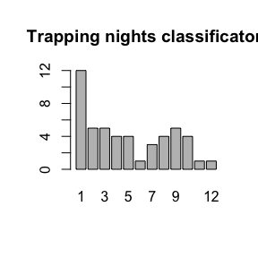

```r
barplot(table(trichometeo$cla), main="Trapping nights classificaton")
```

A full description of the data set (in French) is available [at this page](http://pbil.univ-lyon1.fr/R/pdf/pps034.pdf).

## Poisson log-normal models

The family of models available in the package belongs to the family of probabilistic PCA models, where the observation are not necessarily Gaussian. In particular, we consider that observations are drawn from a Poisson distribution.

### A quick view of the mathematical formulation of the model

The Poisson lognormal model relates some $p$-dimensional observation vectors $\mathbf{Y}_i$ to some $p$-dimensional vectors of Gaussian latent variables $\mathbf{Z}_i$ as follows
$$\begin{equation}
\label{eq:pca-model}
\begin{array}{rcl}
\text{latent space } & \mathbf{Z}_i \sim \mathcal{N}{\boldsymbol\mu},\boldsymbol\Sigma) \\
\text{observation space } & Y_{ij} | Z_{ij} \quad \text{indep.} & Y_{ij} | Z_{ij} \sim \mathcal{P}\left(\exp\{Z_{ij}\}\right)
\end{array}
\end{equation}$$

The parameter ${\boldsymbol\mu}$ corresponds to the main effects and the latent covariance matrix $\boldsymbol\Sigma$ describes the underlying structure of dependence between the $p$ variables.

In the PLN network, we penalized the inverse covariance $\boldsymbol\Sigma^{-1} = \boldsymbol\Theta$ by a $\ell_1$ penalty to induce sparsity and select important direct relationships between entities. Hence, the support of $\boldsymbol\Theta$ correspond to a network of underlying interactions.

### A model with latent main effects for the Trichopetra data set

We start by adjusting the above model to Trichoptera data set. Here, the matrix of observations $\mathbf{Y}$ corresponds to the abundance of each species in each trapping night. The model can be fitted with the function `PLNNetwork` for a series of penalties contorling the number of edges in the network as follows:

```r
abundance <- as.matrix(trichometeo$fau) ## must be a matrix
models <- PLNnetwork(abundance ~ 1)
```

[output not shown]

Note the use of the `formula` object to specify the model: the vector $\boldsymbol\mu$ of main effects in the mathematical formulation (one per column species) is specified in the call with the formula `~ 1`.

The `models` variable is an `R6` object with class `PLNnetworkfamily`, which comes with a couple of methods. The most basic is the `show/print` method, which send a very basic summary of the estimation process:

```r
models
```

```
## --------------------------------------------------------
## COLLECTION OF 30 POISSON LOGNORMAL MODELS
## --------------------------------------------------------
##  Task: Network Inference
## ========================================================
##  - 30 penalties considered: from 0.3918085 to 7.83617
##     use $penalties to see all values and access specific lambdas
##  - Best model (regarding BIC): lambda = 0.895
```

Complementary information comes with the `plot` method:

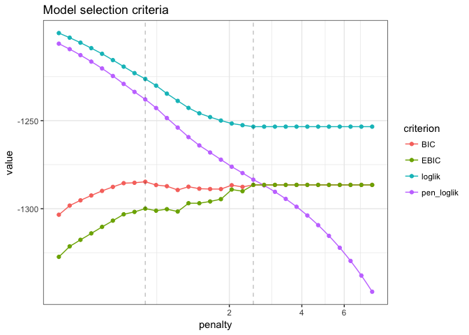

```r
models$plot()
```

We can represent the coefficient path (i.e., value of the edge in the network according to the penalty level) to see if some edges clearly come off.

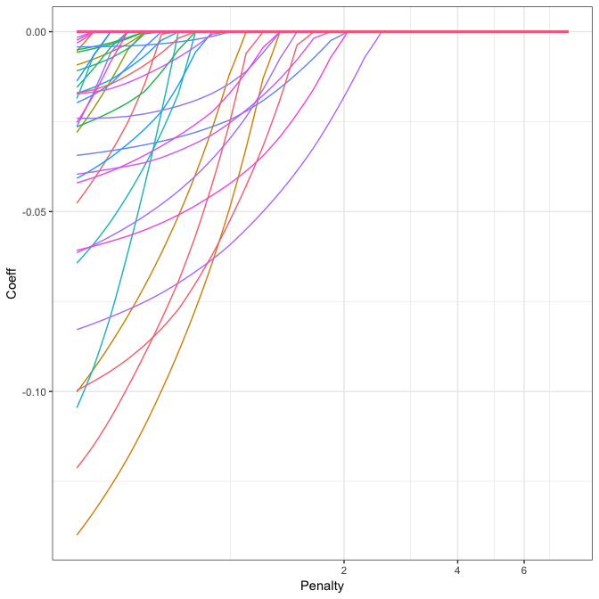

```r
library(ggplot2)
path <- models$coefficient_path(corr = FALSE)
ggplot(path, aes(x = Penalty, y = Coeff, group = Edge, colour = Edge)) + geom_line(show.legend = FALSE) +  coord_trans(x="log10") + theme_bw()
```

An alternative and more intuitive view consiste in plotting the values of the partial correlation along the path.

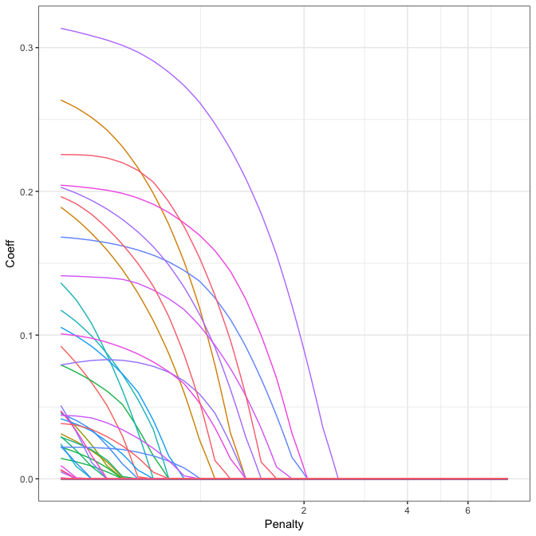

```r
path <- models$coefficient_path(corr = TRUE)
ggplot(path, aes(x = Penalty, y = Coeff, group = Edge, colour = Edge)) + geom_line(show.legend = FALSE) + coord_trans(x="log10") + theme_bw()
```

#### Model selection issue

If we want to select one network, we may extract best model according to BIC or StARS with the method `getBestModel()`. A model with a specific penalty level can be extracted with the `getModel(lambda)` method.

```r
model.BIC   <- models$getBestModel("BIC")   # if no criteria is specified, the best BIC is used
model.StARS <- models$getBestModel("StARS") # if StARS is requested, stabiltiy selection is performed if needed
```

```
##
## Stability Selection for PLNnetwork:
## subsampling: ++++++++++++++++++++
```

```r
model.pen   <- models$getModel(models$penalties[20]) # give some sparsity
```

The variables `model.BIC`, `model.StARS` and `model.pen` are other `R6Class` objects of class `PLNnetworkfit` which in turns owns a couple of methods, mostly for vizualization purposes. The `plot_network` method provides a quick representation of the inferred network, with various options.

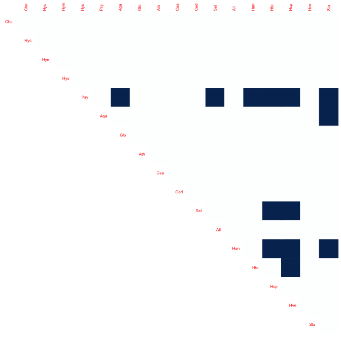

```r
model.BIC$plot_network(type = "support", output = "corrplot")
```

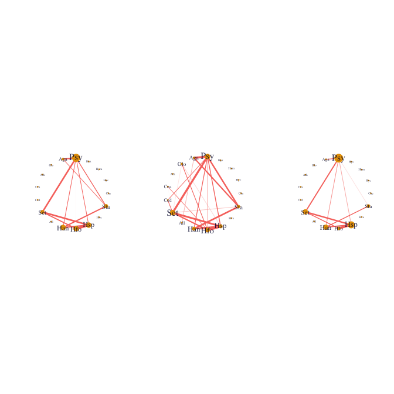

```r
par(mfrow = c(1, 3))
model.BIC$plot_network()
model.StARS$plot_network()
model.pen$plot_network()
```

Additional information about the optimization process comes with the `plot_objective` method:

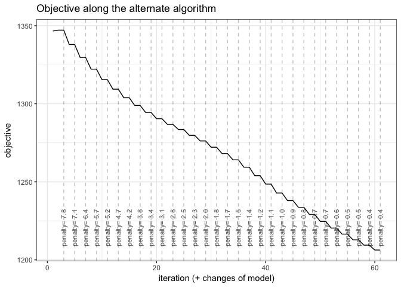

```r
models$plot_objective()
```